# Introduction to GDSC data

Ricardo Ramirez

1/14/2020

# Introduction

Here we will work with a reduced dataset coming from the Genomics of Drug Sensitivity in Cancer panel from Sanger Institute.

In this notebook we will apply some basic transcriptomics analysis, functional genomics and network biology concepts to answer questions around drug sensitivity in colon cancer.

#### First make sure to install all required dependencies

```r
# If not installed, follow:
# install.packages("package")
library(tidyr)
library(dplyr)
library(purrr)
library(curl)
library(devtools)
library(ggplot2)
library(corrplot)
# From Bioconductor
# If not installed, follow:
# BiocManager::install("package")
library(viper)
library(progeny)
library(fgsea)
```

#### Then load all datasets needed for this practical

```r
colon_cells <- readRDS("data/colon_cells.rds")
colon_IC50s <- readRDS(file = "data/colon_IC50s.rds") %>%
  dplyr::filter(DATASET == "GDSC1") %>%
  dplyr::mutate(COSMIC_ID = as.character(COSMIC_ID),
                DRUG_ID = as.character(DRUG_ID)) %>%
  dplyr::select(COSMIC_ID, DRUG_ID, DRUG_NAME, IC50_PUBLISHED)

colon_gex <- readRDS(file = "data/colon_gex.rds")
load("data/TEDDY_geneSets.ro")

hmarks_gsets <- TEDDY_geneSets$MSIGDB_HMARKS
```

#### Part 1: Data visualization and understanding the data

Let’s discuss what type of analyses shall we perform before

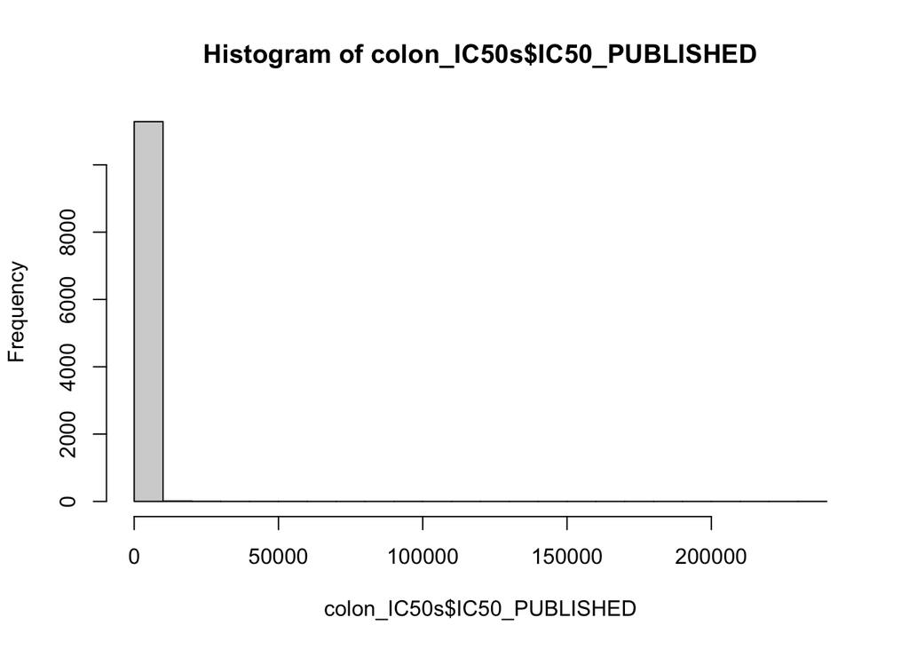

```r
hist(colon_IC50s$IC50_PUBLISHED,breaks = 30)
```

```r
min(colon_IC50s$IC50_PUBLISHED)
```

```
## [1] 0.0003981256
```

```r
max(colon_IC50s$IC50_PUBLISHED)
```

```
## [1] 233209.9
```

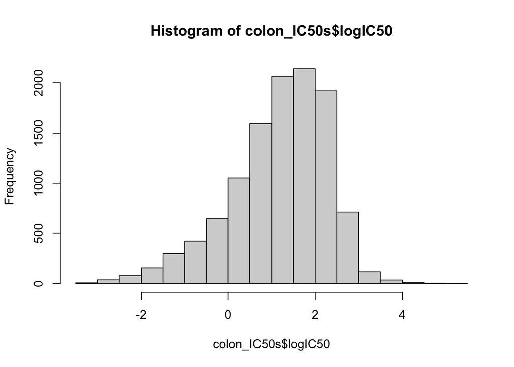

```r
colon_IC50s$logIC50 <- log10(colon_IC50s$IC50_PUBLISHED)
hist(colon_IC50s$logIC50)
```

What is the most effective drug?

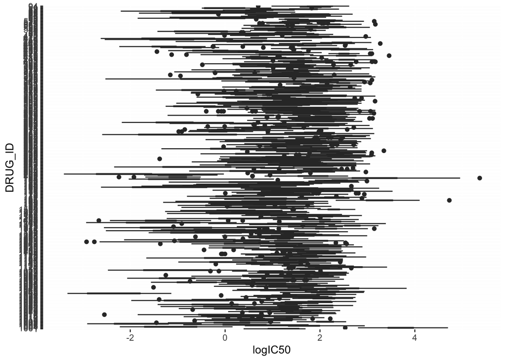

```r
ggplot(colon_IC50s, aes(y = DRUG_ID,
                        x = logIC50)) +
  geom_boxplot()
```

```r
drug_responses_stats <- colon_IC50s %>%
  dplyr::group_by(DRUG_ID) %>%
  summarise(mean_ic50 = mean(logIC50, na.rm = TRUE),
            var_ic50 = var(logIC50, na.rm = TRUE))
```

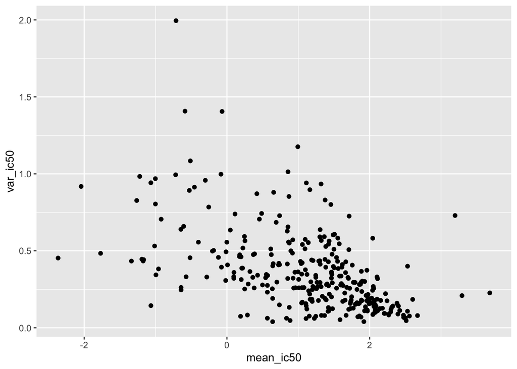

```r
ggplot(drug_responses_stats, aes(x = mean_ic50, y = var_ic50)) +
  geom_point()
```

I will select a drug that shows high variability of response

```r
drug_responses_stats %>%
  dplyr::filter(mean_ic50 > 2) %>%
  dplyr::arrange(-var_ic50) %>%
  slice(1) %>%
  pull(DRUG_ID)
```

```
## [1] "196"
```

Another question to the data, do cells group similarly from gene expression data and their drug response

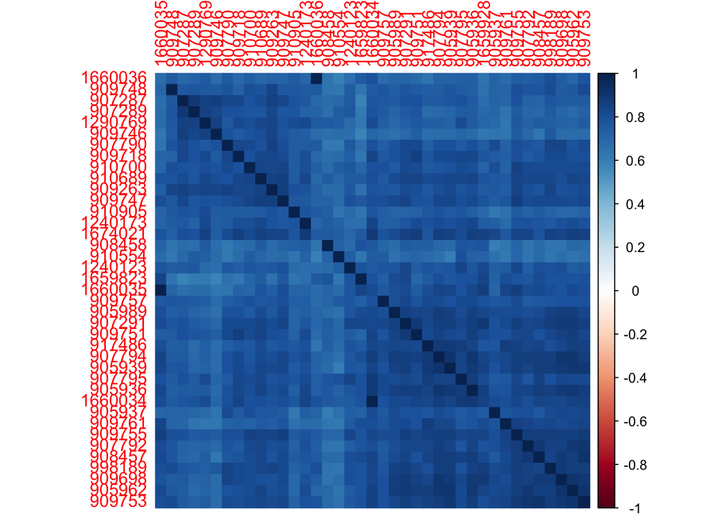

```r
colon_IC50s_mat <- colon_IC50s %>%
  dplyr::select(COSMIC_ID, DRUG_ID, logIC50) %>%
  tidyr::pivot_wider(values_from = logIC50,
                     names_from = COSMIC_ID)

drug_rows <- colon_IC50s_mat$DRUG_ID
colon_IC50s_mat <- as.matrix(colon_IC50s_mat[,-1])
rownames(colon_IC50s_mat) <- drug_rows

cor_mat <- cor(colon_IC50s_mat, use = "pairwise.complete.obs")
cor_mat <- na.omit(cor_mat)

corrplot(cor_mat,method = "color",order = "hclust")
```

```r
bleomycin_IC50s <- colon_IC50s %>% dplyr::filter(DRUG_ID == "1017",
                                                COSMIC_ID %in% colon_cells$COSMIC_ID)

# Here I filter my cell table to contain only cell lines that were treated with my selected drug
bleomycin_cells <- colon_cells %>%
  dplyr::mutate(COSMIC_ID = as.character(COSMIC_ID)) %>%
  dplyr::filter(COSMIC_ID %in% bleomycin_IC50s$COSMIC_ID)

# Here I add the IDs from my expression matrix to my drug response data
bleomycin_IC50s <- left_join(bleomycin_IC50s, bleomycin_cells[,c("DepMap_ID", "COSMIC_ID")])
# Same order of IC50s and gene expression
colon_gex_filtered <- colon_gex[,bleomycin_IC50s$DepMap_ID]
# Filter genes that have more than 50% of data == 0
good_rows <- rowSums(colon_gex_filtered == 0) <
            (ncol(colon_gex_filtered))/2
# Final GEX matrix
colon_gex_filtered <- colon_gex_filtered[good_rows,]
genes <- rownames(colon_gex_filtered)
```

1. After what you heard of this dataset, what type of questions could be solved and why network biology + systems biology is useful here?

# Gene analysis / Gene set enrichment analysis

1. Get one drug to test for responses

```r
# Here we perform a linear model of DrugResponse~GeneExpression
# Remember that this is an example and many assumptions have to be
# done to the data!! Don't forget your stats course :-)

lm_summary = data.frame(t(sapply(genes,function(gene){
       modelDF = tibble("Expression" = colon_gex_filtered[gene,],
                        "Response" = bleomycin_IC50s$logIC50)

       lmres = lm(Response~Expression,data = modelDF)
       lmres = summary(lmres)$coefficients[2,c(3,4)]
       names(lmres) = c("t","p_value")

       return(lmres)
})))

lm_summary = lm_summary %>%
             mutate("gene" = rownames(lm_summary),
                    "adj_pval" = p.adjust(p_value,"BH")) %>%
             arrange(desc(t))

dim(lm_summary)
```

```
## [1] 16091     4
```

```r
head(lm_summary)
```

```
##          t      p_value    gene   adj_pval
## 1 5.798544 9.864804e-07   ADAP1 0.01240603
## 2 5.658811 1.541984e-06  ARRDC1 0.01240603
## 3 5.228664 6.072445e-06    PKP3 0.01415119
## 4 5.187323 6.923697e-06 TMEM45B 0.01415119
## 5 5.187250 6.925295e-06 TMEM30B 0.01415119
## 6 5.006929 1.225325e-05     SYK 0.01488854
```

```r
pval_sign = lm_summary %>%
            filter(adj_pval < 0.05) %>%
  as_tibble()
```

2. OK we can make plots just to understand what’s happening
- A positive slope would represent that the expression of the genes contribute to resistance

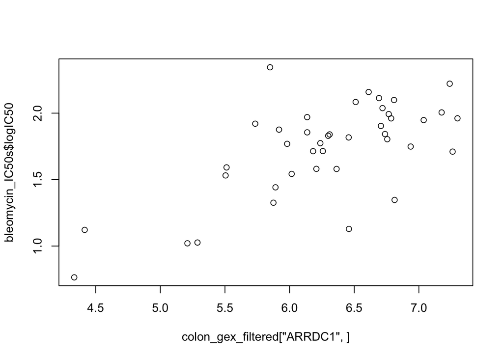

```r
plot(colon_gex_filtered["ARRDC1",],
     bleomycin_IC50s$logIC50)
```

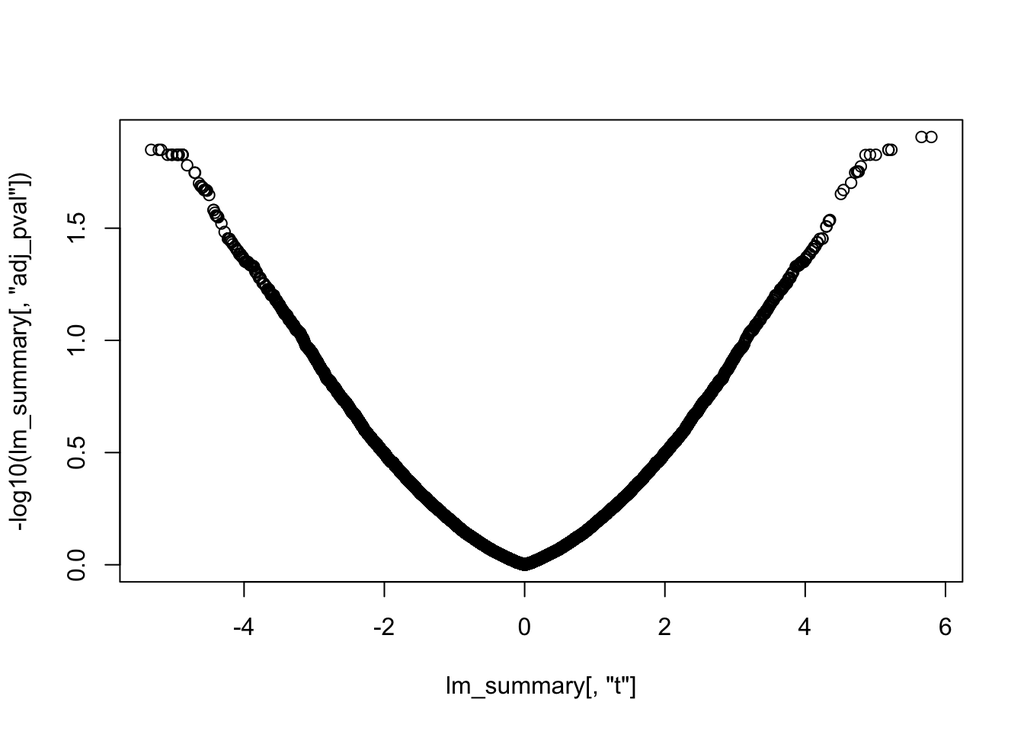

```r
plot(lm_summary[,"t"],
     -log10(lm_summary[,"adj_pval"]))
```

3. What if we wanted to know which processes are involved in resistance?

```r
## Function to perform Hypergeometric Tests for gene set enrichment
## Input:
## geneList = query gene list to enrich
## Annotation_DB = a list of gene sets to enrich in geneList
## Output: data frame with results

GSE_analysis = function(geneList,Annotation_DB){

  geneList = geneList[geneList %in% unique(unlist(Annotation_DB))]

  ResultsDF = matrix(0,nrow = length(Annotation_DB),ncol = 5)
  rownames(ResultsDF) = names(Annotation_DB)
  colnames(ResultsDF) = c("GenesInPathway","GenesInList","GeneNames","p_value","corr_p_value")

  DB_genecontent = length(unique(unlist(Annotation_DB)))

  GenesDB = DB_genecontent
  SelectedGenes = length(geneList)

  for(gset in rownames(ResultsDF)){
    GP = length(Annotation_DB[[gset]])
    GL = length(intersect(Annotation_DB[[gset]],geneList))

    ResultsDF[gset,"GenesInList"] = GL
    ResultsDF[gset,"GenesInPathway"] = GP
    ResultsDF[gset,"GeneNames"] = paste(intersect(Annotation_DB[[gset]],geneList),collapse = ",")
    #ResultsDF[gset,"p_value"] = HypergeometricTest(overRepres = TRUE,N = N,K = K,n = n,k = k)
    ResultsDF[gset,"p_value"] = phyper(q=GL - 1, m=GP, n=GenesDB-GP, k=SelectedGenes, lower.tail = FALSE, log.p = FALSE)
  }

  ResultsDF[,"corr_p_value"] = p.adjust(ResultsDF[,"p_value"],method = "BH")
  ResultsDF = data.frame(ResultsDF,stringsAsFactors = F)
  ResultsDF = ResultsDF[order(ResultsDF[,"p_value"]),]

  return(ResultsDF)

}
```

```r
# Overrepresentation analysis for homework ;)
# Look for hypergeometric tests

resistance_genes <- pval_sign %>%
  dplyr::filter(t > 0) %>%
  pull(gene)

sensitivity_genes <-  pval_sign %>%
  dplyr::filter(t < 0) %>%
  pull(gene)

fisher_pvals = GSE_analysis(geneList = resistance_genes,
             Annotation_DB = hmarks_gsets)

fisher_pvals = GSE_analysis(geneList = sensitivity_genes,
             Annotation_DB = hmarks_gsets)

# Let's apply GSEA
t_vals = lm_summary$t
names(t_vals) = lm_summary$gene

enrichment_res = fgsea(hmarks_gsets,
                       stats = t_vals)
# Let's look at the results

enrichment_res = data.frame(enrichment_res) %>%
                 arrange(desc(abs(NES)))

enrichment_res_filtered = enrichment_res %>%
                          dplyr::filter(pval<0.05)

enrichment_res_filtered[1:5,-8]
```

```
##                     pathway         pval         padj   log2err         ES
## 1 INTERFERON_ALPHA_RESPONSE 1.000000e-10 1.666667e-09        NA  0.5708387
## 2               E2F_TARGETS 1.000000e-10 1.666667e-09        NA -0.5325241
## 3            G2M_CHECKPOINT 1.000000e-10 1.666667e-09        NA -0.4873218
## 4    ESTROGEN_RESPONSE_LATE 5.873258e-10 7.341572e-09 0.8012156  0.3945696
## 5            MYC_TARGETS_V1 2.496773e-09 2.496773e-08 0.7749390 -0.4461670
##         NES size
## 1  2.718260   92
## 2 -2.457685  195
## 3 -2.244890  192
## 4  2.104586  194
## 5 -2.058058  196
```

# TF activities

```r
## We read Dorothea Regulons for Human:
## We obtain the regulons based on interactions with confidence level A, B and C

data(dorothea_hs, package = "dorothea")
regulons = dorothea_hs

regulon = regulons %>%
    dplyr::filter(confidence %in% c("A","B","C")) %>%
    dorothea::df2regulon()
```

#### Getting TF activities and associations with drug response

```r
# Running viper
colon_tfs = viper(eset = colon_gex_filtered,
                  regulon = regulon,
                  verbose = F)
dim(colon_tfs)
```

```
## [1] 166  41
```

```r
tfs = rownames(colon_tfs)

#Running linear models
tfs_lm_summary = data.frame(t(sapply(tfs,function(tf){
       modelDF = tibble("Expression" = colon_tfs[tf,],
                        "Response" = bleomycin_IC50s$logIC50)

       lmres = lm(Response~Expression,data = modelDF)
       lmres = summary(lmres)$coefficients[2,c(3,4)]
       names(lmres) = c("t","p_value")

       return(lmres)
})))

tfs_lm_summary = tfs_lm_summary %>%
                 mutate("TF" = rownames(tfs_lm_summary),
                        "adj_pval" = p.adjust(p_value,"BH")) %>%

                 arrange(desc(t)) %>%
                 dplyr::filter(p_value<0.05)

dim(tfs_lm_summary)
```

```
## [1] 39  4
```

```r
head(tfs_lm_summary)
```

```
##          t      p_value    TF   adj_pval
## 1 4.580993 0.0000465191  KLF5 0.00772217
## 2 3.718601 0.0006287811 GRHL2 0.04306201
## 3 3.478132 0.0012563820 TFAP4 0.04921322
## 4 3.395383 0.0015874027  ELF3 0.04921322
## 5 3.208469 0.0026681869 KLF13 0.04921322
## 6 3.028989 0.0043380870  KLF6 0.06089574
```

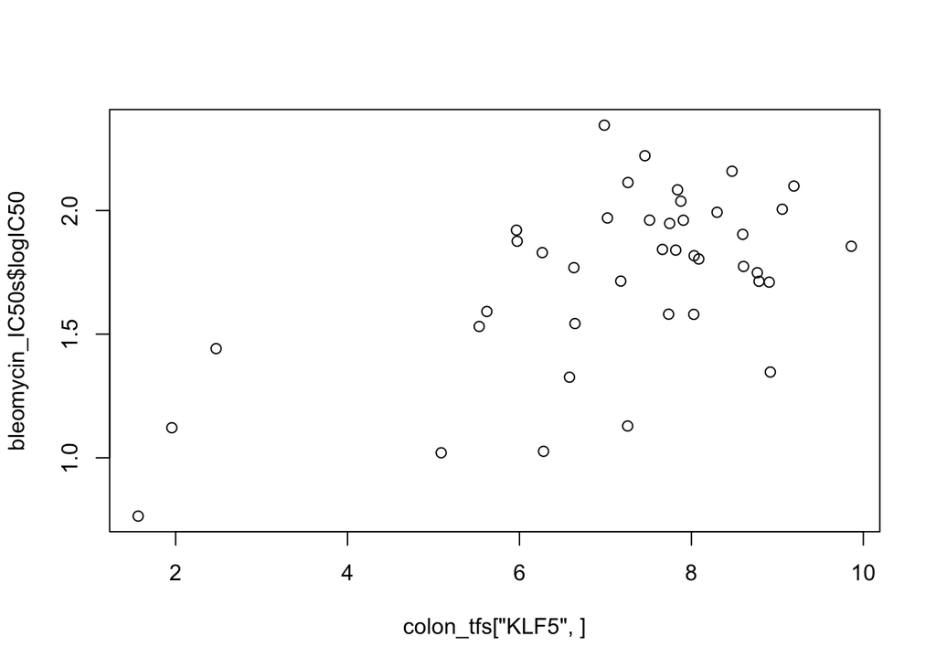

```r
plot(colon_tfs["KLF5",],
     bleomycin_IC50s$logIC50)
```

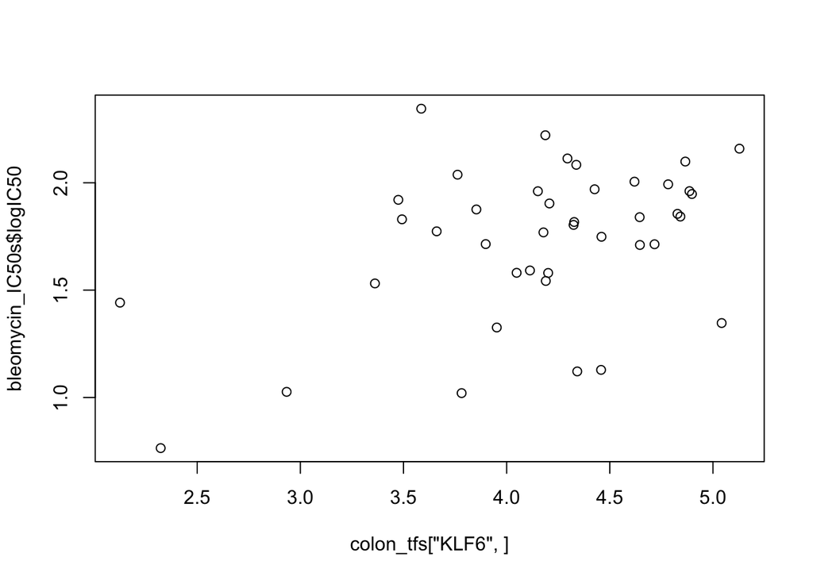

```r
plot(colon_tfs["KLF6",],
     bleomycin_IC50s$logIC50)
```

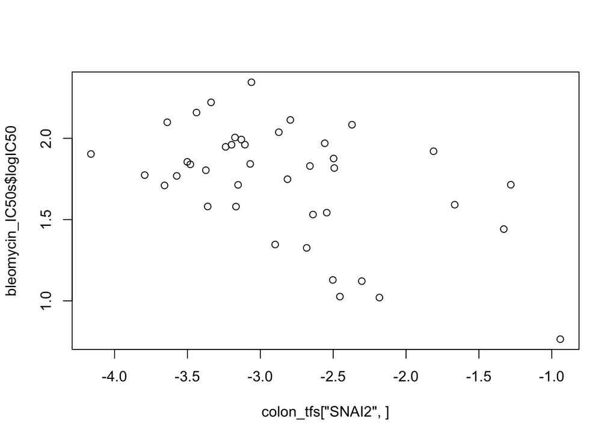

```r
plot(colon_tfs["SNAI2",],
     bleomycin_IC50s$logIC50)
```

# PROGENy

1. What’s the difference between this approach and GSEA?

#### Here we first calculate pathway activities and then we associate them with drug response

```r
progeny_colon = t(progeny(expr = colon_gex_filtered))
progeny_colon[1:5,1:5]
```

```
##           ACH-000971 ACH-000997  ACH-000552  ACH-000651 ACH-000969
## Androgen  0.04396588 -0.6211890  0.35268086  1.06965673 -1.2846329
## EGFR      1.99985172 -0.9547601 -0.66941313  0.06441476 -0.7095657
## Estrogen  0.42588387  0.1512153 -0.90653169  1.17308387 -0.5913276
## Hypoxia   1.15686955  1.0746867 -0.06405382 -0.55635581 -1.1040973
## JAK-STAT -0.81546917 -0.3662111 -0.86351740 -1.09620598 -1.0609003
```

```r
pathways = rownames(progeny_colon)

path_lm_summary = data.frame(t(sapply(pathways,function(pathway){
       modelDF = tibble("Expression" = progeny_colon[pathway,],
                        "Response" = bleomycin_IC50s$logIC50)

       lmres = lm(Response~Expression,data = modelDF)
       lmres = summary(lmres)$coefficients[2,c(3,4)]
       names(lmres) = c("t","p_value")

       return(lmres)
})))

path_lm_summary = path_lm_summary %>%
                 mutate("Pathway" = rownames(path_lm_summary),
                        "adj_pval" = p.adjust(p_value,"BH")) %>%
                 arrange(desc(t)) %>%
                 dplyr::filter(p_value<0.1)

dim(path_lm_summary)
```

```
## [1] 4 4
```

```r
path_lm_summary
```

```
##           t     p_value Pathway   adj_pval
## 1  1.774243 0.083830213     WNT 0.29340574
## 2 -2.115314 0.040843664    TGFb 0.19060376
## 3 -2.125321 0.039948696    VEGF 0.19060376
## 4 -3.399542 0.001568942    PI3K 0.02196518
```

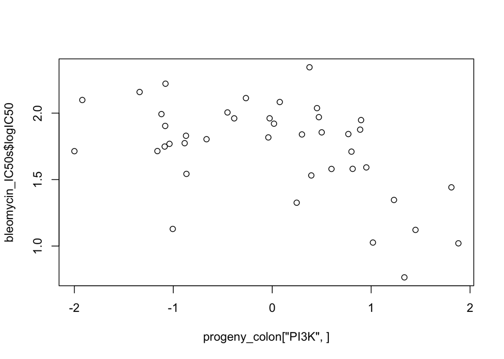

```r
plot(progeny_colon["PI3K",],
     bleomycin_IC50s$logIC50)
```

#### Comparison with GSEA

```r
enrichment_res_filtered$pathway
```

```
##  [1] "INTERFERON_ALPHA_RESPONSE"         "E2F_TARGETS"
##  [3] "G2M_CHECKPOINT"                    "ESTROGEN_RESPONSE_LATE"
##  [5] "MYC_TARGETS_V1"                    "ESTROGEN_RESPONSE_EARLY"
##  [7] "TNFA_SIGNALING_VIA_NFKB"           "EPITHELIAL_MESENCHYMAL_TRANSITION"
##  [9] "INTERFERON_GAMMA_RESPONSE"         "ANGIOGENESIS"
## [11] "CHOLESTEROL_HOMEOSTASIS"           "P53_PATHWAY"
## [13] "OXIDATIVE_PHOSPHORYLATION"         "APOPTOSIS"
## [15] "DNA_REPAIR"                        "WNT_BETA_CATENIN_SIGNALING"
## [17] "SPERMATOGENESIS"                   "IL2_STAT5_SIGNALING"
## [19] "KRAS_SIGNALING_UP"                 "IL6_JAK_STAT3_SIGNALING"
## [21] "MTORC1_SIGNALING"                  "HYPOXIA"
```

```r
sort(names(hmarks_gsets)[!names(hmarks_gsets) %in%
                       enrichment_res_filtered$pathway])
```

```
##  [1] "ADIPOGENESIS"                    "ALLOGRAFT_REJECTION"
##  [3] "ANDROGEN_RESPONSE"               "APICAL_JUNCTION"
##  [5] "APICAL_SURFACE"                  "BILE_ACID_METABOLISM"
##  [7] "COAGULATION"                     "COMPLEMENT"
##  [9] "FATTY_ACID_METABOLISM"           "GLYCOLYSIS"
## [11] "HEDGEHOG_SIGNALING"              "HEME_METABOLISM"
## [13] "INFLAMMATORY_RESPONSE"           "KRAS_SIGNALING_DN"
## [15] "MITOTIC_SPINDLE"                 "MYC_TARGETS_V2"
## [17] "MYOGENESIS"                      "NOTCH_SIGNALING"
## [19] "PANCREAS_BETA_CELLS"             "PEROXISOME"
## [21] "PI3K_AKT_MTOR_SIGNALING"         "PROTEIN_SECRETION"
## [23] "REACTIVE_OXIGEN_SPECIES_PATHWAY" "TGF_BETA_SIGNALING"
## [25] "UNFOLDED_PROTEIN_RESPONSE"       "UV_RESPONSE_DN"
## [27] "UV_RESPONSE_UP"                  "XENOBIOTIC_METABOLISM"
```